# Project_3

## Project 3 CMSC 320

Within this notebook, we will accomplish two tasks. Firstly, explore linear regression over the gapminder dataset about life expectancy across the years. Then, we will the compare machine learning models to see how accuracy varies. We will conduct our analysis throughout this notebook using various statistical tests in order to support our claims. Small alterations have been made to this project in order for it to be more clearly understood for readers without the questions bank for this assignment

```python
!pip install ggplot
import pandas as pd
import seaborn as sb
from ggplot import *
from sklearn.linear_model import LinearRegression
from sklearn.datasets import make_regression
from sklearn.datasets import load_iris
from sklearn.svm import LinearSVC
from sklearn.model_selection import cross_val_score
from sklearn import tree
import numpy as np
import matplotlib.pyplot as plt
from scipy.stats import ttest_ind
from scipy.stats import ttest_rel
import statsmodels.formula.api as sm
import statsmodels.api as smapi
from sklearn.model_selection import KFold

%matplotlib inline
np.seterr(under='ignore');
np.seterr(over='ignore');
```

## Part 1

Creating a scatter plot of life expectancy between the years of 1952 to 2007.

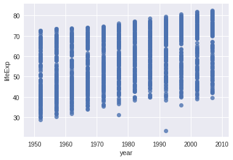

```python
life_data = pd.read_csv("gap.tsv", sep='\t')
sb.regplot(x='year', y='lifeExp', data=life_data, fit_reg=False)
```

We will begin generating the violin plots for analysis.

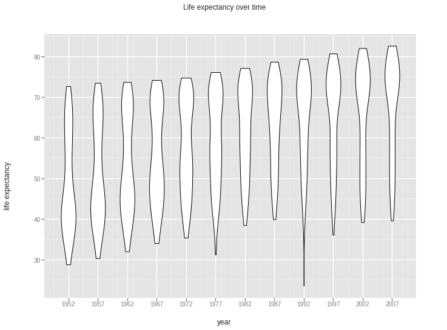

```python
ggplot(aes(x='year', y='lifeExp'), data=life_data) +\
    geom_violin() +\
    labs(title="Life expectancy over time",
         x = "year",
         y = "life expectancy")
```

Based on the violin plot of life expectancy to year, we can make multiple obersvations. Until 1967, the life expectance is skewed towards the lower years. I can not confidently comment on the modality of the distribution. From 1967 to 1982, we see that the distributions look somewhat bimodal. From 1982 to 2007, the data is skewed towards the higher years and I can not comment on the modality of the distribution. Throughout all of the years, the data does not appear symmetric about its center. Considering a hypothesis test over this dataset where $H_0$ = no relationship between year and life expectancy. Yes, I would reject H0 since, solely based the the previous visualizations. There appears to be a linear relationship between the two variables in question. Finally, Since I'm assuming the relationship is, in fact, linear, I would expect the points on the residual graph to also be linear. Since we are confident that there should be a linear relationship, let's train the model and see how it fits.

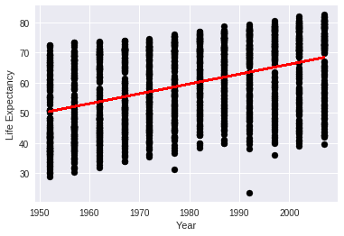

```python
# invoke scikit linear regression tool
linear_model = LinearRegression()
life_data_X = life_data.year.values
life_data_Y = life_data.lifeExp.values
x = life_data_X.reshape(len(life_data.year), 1)
y = life_data_Y.reshape(len(life_data.year), 1)
linear_model.fit(x,y)

# plotting the fitted line to the datset
plt.scatter(x, y, color='black')
plt.plot(x, linear_model.predict(x), color='red', linewidth=2)
plt.xlabel('Year')
plt.ylabel('Life Expectancy')
plt.show()
```

Based on the output from scikit's LinearRegression, we see a positive change in life expectancy of .3259 per year

```python
print(linear_model.coef_)
```

```
[[ 0.32590383]]
```

### Exercise 3

Below we create a violin plot to visualize the residuals between the true life expectancy and the predicted values.

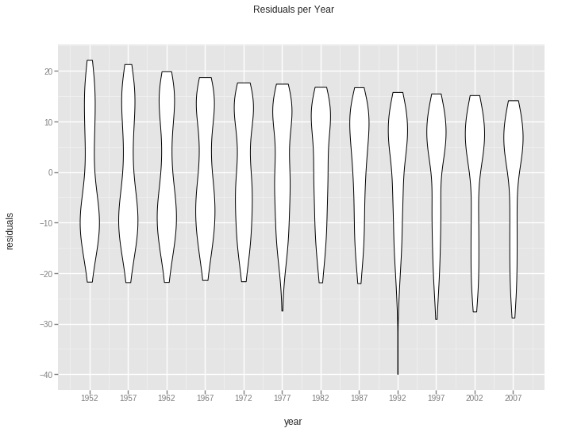

```python
# get the predicted values based on the model and compute error
true_y = np.asarray(life_data_Y, dtype=np.float32)
predicted_y = np.asarray(linear_model.predict(x), dtype=np.float64)
predicted_y = predicted_y.flatten()
life_data['residuals'] = true_y - predicted_y

ggplot(aes(x='year', y='residuals'), data=life_data) +\
    geom_violin() +\
    labs(title="Residuals per Year",
         x = "year",
         y = "residuals")
```

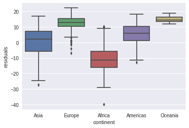

```python
sb.boxplot(x="continent", y="residuals", data=life_data)
```

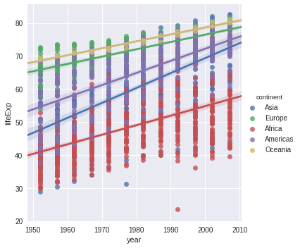

```python
sb.lmplot(x="year", y="lifeExp", hue="continent", data=life_data)
```

In the above graph, we see the life expectancy per year as shown in the previous examples. Each continent has been color coated with their respective regression line. The slopes for the regression lines of each continent's sample is different. This is the most evident when we compare the regression line for Asia with the regression line for Oceania.

Now, we will create a regression model with a new interaction term between year and continent. We then display the formatted output of the regression results.

```python
# including the categorical element for our model
regression_model = sm.ols(formula='lifeExp ~ year * continent', data=life_data)
results = regression_model.fit()
results.summary()
```

OLS Regression Results

| Dep. Variable: | lifeExp | R-squared: | 0.693 |
| --- | --- | --- | --- |
| Model: | OLS | Adj. R-squared: | 0.691 |
| Method: | Least Squares | F-statistic: | 424.3 |
| Date: | Mon, 12 Feb 2018 | Prob (F-statistic): | 0.00 |
| Time: | 22:11:06 | Log-Likelihood: | -5771.9 |
| No. Observations: | 1704 | AIC: | 1.156e+04 |
| Df Residuals: | 1694 | BIC: | 1.162e+04 |
| Df Model: | 9 |  |  |
| Covariance Type: | nonrobust |  |  |

|  | coef | std err | t | P>\|t\| | [0.025 | 0.975] |
| --- | --- | --- | --- | --- | --- | --- |
| Intercept | -524.2578 | 32.963 | -15.904 | 0.000 | -588.911 | -459.605 |
| continent[T.Americas] | -138.8484 | 57.851 | -2.400 | 0.016 | -252.315 | -25.382 |
| continent[T.Asia] | -312.6330 | 52.904 | -5.909 | 0.000 | -416.396 | -208.870 |
| continent[T.Europe] | 156.8469 | 54.498 | 2.878 | 0.004 | 49.957 | 263.737 |
| continent[T.Oceania] | 182.3499 | 171.283 | 1.065 | 0.287 | -153.599 | 518.298 |
| year | 0.2895 | 0.017 | 17.387 | 0.000 | 0.257 | 0.322 |
| year:continent[T.Americas] | 0.0781 | 0.029 | 2.673 | 0.008 | 0.021 | 0.135 |
| year:continent[T.Asia] | 0.1636 | 0.027 | 6.121 | 0.000 | 0.111 | 0.216 |
| year:continent[T.Europe] | -0.0676 | 0.028 | -2.455 | 0.014 | -0.122 | -0.014 |
| year:continent[T.Oceania] | -0.0793 | 0.087 | -0.916 | 0.360 | -0.249 | 0.090 |

| Omnibus: | 27.121 | Durbin-Watson: | 0.242 |
| --- | --- | --- | --- |
| Prob(Omnibus): | 0.000 | Jarque-Bera (JB): | 44.106 |
| Skew: | -0.121 | Prob(JB): | 2.65e-10 |
| Kurtosis: | 3.750 | Cond. No. | 2.09e+06 |

Based off of the summary above [*more specificaly the coefficient of determination*] we can see that using this new categorical variables gives us a good fit for a linear model.

We can now extract the parameters from the model and tidy the data to show the average change in life expectancy for each continent per year.`

```python
# extract the coefficients from the model output summary
continent_data = results.params
life_by_continent_df = pd.DataFrame()

# grabbing all of the slopes
year_slope = continent_data['year']
america_slope = continent_data['year:continent[T.Americas]']
asia_slope = continent_data['year:continent[T.Asia]']
europe_slope = continent_data['year:continent[T.Europe]']
oceania_slope = continent_data['year:continent[T.Oceania]']

life_by_continent_df['continents'] = ['America', 'Asia', 'Europe', 'Oceania']
life_by_continent_df['delta_expectancy'] = [year_slope+america_slope, year_slope+asia_slope,
                                            year_slope+europe_slope, oceania_slope+year_slope]

life_by_continent_df
```

|  | continents | delta_expectancy |
| --- | --- | --- |
| 0 | America | 0.367651 |
| 1 | Asia | 0.453122 |
| 2 | Europe | 0.221932 |
| 3 | Oceania | 0.210272 |

Now that the data is tidy, we will run an ANOVA Test to determine how well the two models fit the data.

```python
# create the linear models over both data sets
year_continent_model = sm.ols(formula='lifeExp ~ year * continent', data=life_data).fit()
year_model = sm.ols(formula='lifeExp ~ year', data=life_data).fit()

smapi.stats.anova_lm(year_model, typ=2)
```

|  | sum_sq | df | F | PR(>F) |
| --- | --- | --- | --- | --- |
| year | 53919.184217 | 1.0 | 398.604746 | 7.546795e-80 |
| Residual | 230229.199536 | 1702.0 | NaN | NaN |

```
Above we see the calculated values of the F test over the regression line
for life expectancy per year.
```

```python
smapi.stats.anova_lm(year_continent_model, typ=2)
```

|  | sum_sq | df | F | PR(>F) |
| --- | --- | --- | --- | --- |
| continent | 139343.165923 | 4.0 | 675.811593 | 0.000000e+00 |
| year | 53919.184217 | 1.0 | 1046.027900 | 4.048499e-179 |
| year:continent | 3566.089198 | 4.0 | 17.295462 | 6.463379e-14 |
| Residual | 87319.944414 | 1694.0 | NaN | NaN |

```
Above we see the calculated values of the F test over the regression
line for life expectancy per year with interaction with continent.
```

Based on the output above, the interaction model is better than the year only model since the squared sum of the residuals of the interaction model is lower than the year only model's squared sum residuals. In the end, this shows we have a better fitting model when we consider both the country and the year. With this new information, we can use another violin plot in order to observe the residuals of our interaction.

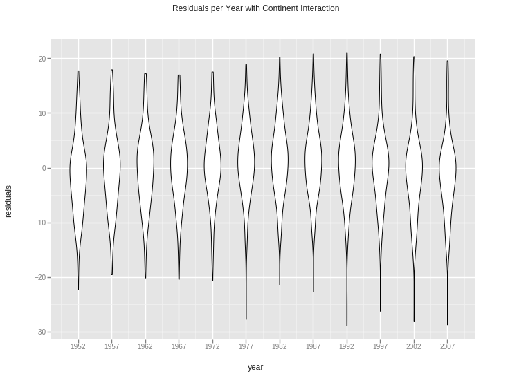

```python
# grab data frome dataframe
life_data_X = life_data.year.values
life_data_Y = life_data.lifeExp.values
x = life_data_X.reshape(len(life_data.year), 1)
y = life_data_Y.reshape(len(life_data.year), 1)
true_y = np.asarray(life_data_Y, dtype=np.float32)

# use model to predict values for year with new model and find residuals
predicted_y = np.asarray(year_continent_model.predict(life_data), dtype=np.float32)
predicted_y = predicted_y.flatten()
life_data['interaction_residuals'] = true_y - predicted_y

#create violin plot for new model
ggplot(aes(x='year', y='interaction_residuals'), data=life_data) +\
    geom_violin() +\
    labs(title="Residuals per Year with Continent Interaction",
         x = "year",
         y = "residuals")
```

In the above Violin plot, we see the residuals per year while taking into account the interaction variable with the continent field. The values are strongly centered around zero which imply a well fitting regression model.

This new graph in still in agreement with the linearity claim we made at the beginning of this notebook. In comparison to the violin plot below (residuals per year), this plot shows that the new model has a better fit given that its densities are much closer to zero throughout the year.

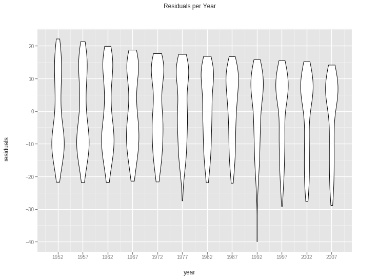

```python
#create violin plot for old model
ggplot(aes(x='year', y='residuals'), data=life_data) +\
    geom_violin() +\
    labs(title="Residuals per Year",
         x = "year",
         y = "residuals")
```

In the above plot, we see the residuals per year. We do **not** take into account information about the current continent. While the values are not as centered as the values in the Residuals per Year with Continent Interaction plot, they are still fairly centered aroundzero which implies a good regression model.

## Part 2

### Try it Yourself

Pick a Dataset and test two ML Models on it.

### Iris Dataset

We will be using SciKit-Learn's Iris dataset for this section. The outcome we are predicting is that given certain measurements of the Iris plant, we will attempt to accurately determine the species of said plant. The predictors in play for this dataset will be the sepal length, sepal width, petal length, and petal width.

```python
# begin loading the data set
iris_data = load_iris()
classes = iris_data.target_names
setosa_index = 0
versicolor_index = 1
virginica_index = 2

#preparing features and labels
X = iris_data.data
y = iris_data.target

#populating a data frame with all information
iris_df = pd.DataFrame(columns=['sepal_length','sepal_width', 'petal_length', 'petal_width'])
for row_num in range(len(X)):
    iris_df.loc[row_num] = X[row_num]

iris_df['species_code'] = y

iris_df['species'] = np.where(iris_df['species_code']==0, classes[setosa_index],
                              (np.where(iris_df['species_code']==1, classes[versicolor_index], classes[virginica_index])))

iris_df.head()
```

|  | sepal_length | sepal_width | petal_length | petal_width | species_code | species |
| --- | --- | --- | --- | --- | --- | --- |
| 0 | 5.1 | 3.5 | 1.4 | 0.2 | 0 | setosa |
| 1 | 4.9 | 3.0 | 1.4 | 0.2 | 0 | setosa |
| 2 | 4.7 | 3.2 | 1.3 | 0.2 | 0 | setosa |
| 3 | 4.6 | 3.1 | 1.5 | 0.2 | 0 | setosa |
| 4 | 5.0 | 3.6 | 1.4 | 0.2 | 0 | setosa |

```python
# building the decision tree and scoring
tree_classifier = tree.DecisionTreeClassifier()
tree_classifier.fit(X,y)
tree_scores = cross_val_score(tree_classifier, X, y, cv=10)

# fitting the model for SVC and scoring
svm_classifier = LinearSVC()
svm_classifier.fit(X,y)
svm_scores = cross_val_score(svm_classifier, X, y, cv=10)
```

#### Accuracy Analysis

We will begin by looking at the accuracy of the classification tree model. As you see below, the 10 fold cross validation procedure determined that the classification tree was able to determine the class of the flower with lowest accuracy of 86% on sample 5.

```
The Standard Error of our estimate is 4.42216638714
```

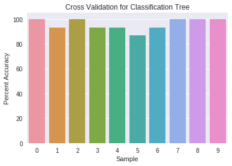

```python
ax = sb.barplot(x=[i for i in range(10)], y=[100*x for x in tree_scores])
ax.set_xlabel('Sample')
ax.set_ylabel('Percent Accuracy')
ax.set_title('Cross Validation for Classification Tree')

print("The Standard Error of our estimate is " + str(100 * np.std(tree_scores)))
```

```
The Standard Error of our estimate is 6.14636297153
```

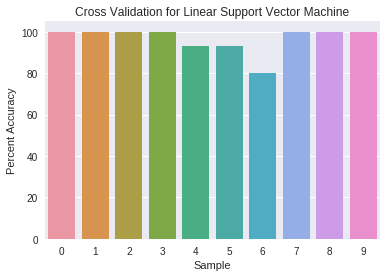

```python
ax = sb.barplot(x=[i for i in range(10)], y=[100*x for x in svm_scores])
ax.set_xlabel('Sample')
ax.set_ylabel('Percent Accuracy')
ax.set_title('Cross Validation for Linear Support Vector Machine')

print("The Standard Error of our estimate is " + str(100 * np.std(svm_scores)))
```

Finally, we perform a paired t test on both the classification tree and support vector machine's cross validation scores to determine whether there is a significant difference between their means.

```python
# Running paired t test against classification tree
_,p = ttest_rel(svm_scores, tree_scores)
print("P-value of " + str(p))
```

```
P-value of 0.726314210889
```

The p value is greater than any commonly used alpha value (.05 or .01) therefore we fail to reject the null hypothesis and say that there is not a significant difference between the true means of the two cross validation estimates. Therefore, in context of our primary question, we do not see a statistically significant difference between the accuracy of the two models.